# ENSAB

Maria Camila Restrepo

2024-11-30

# ENSAB databases

```r
library(here)
library(readr)
#install package MASS if not installed previously
if(!require(MASS)) install.packages("MASS")
library(MASS)
if(!require(survey)) install.packages("survey")
library(survey)
library(tidyverse)
ninoscompleta <- read_delim(
  here("ensab", "M3_NINOS.txt"),
  delim = "|",
  locale = locale(encoding = "Latin1")
)
examen13completa <- read_delim(
  here("ensab", "M4_EXAMEN_1.txt"),
  delim = "|",
  locale = locale(encoding = "Latin1")
)
examen5completa <- read_delim(
  here("ensab", "M4_EXAMEN_2.txt"),
  delim = "|",
  locale = locale(encoding = "Latin1")
)
hogarcompleta <- read_delim(
  here("ensab", "M1_HOGAR.txt"),
  delim = "|",
  locale = locale(encoding = "Latin1")
)
```

We have a total of 6446 children for the sample size

```r
glimpse(ninoscompleta)
```

```
## Rows: 6,446
## Columns: 127
## $ ÿDANE           <dbl> 5001, 5001, 5001, 5001, 5001, 5001, 5001, 5001, 5001, …
## $ MPIO            <chr> "MEDELLIN", "MEDELLIN", "MEDELLIN", "MEDELLIN", "MEDEL…
## $ DPTO            <chr> "ANTIOQUIA", "ANTIOQUIA", "ANTIOQUIA", "ANTIOQUIA", "A…
## $ M3_100C         <dbl> 5, 3, 5, 5, 1, 5, 3, 5, 1, 5, 5, 1, 3, 3, 1, 1, 1, 5, …
## $ M3_103A         <dbl> 1, 2, 1, 1, 2, 1, 2, 1, 2, 1, 1, 2, 2, 2, 2, 2, 2, 1, …
## $ M3_103B         <chr> "NULL", "1", "NULL", "NULL", "1", "NULL", "1", "NULL",…
## $ M3_104          <dbl> 1, 1, 1, 1, 1, 1, 1, 1, 1, 1, 1, 1, 1, 1, 1, 1, 1, 1, …
## $ M3_107          <chr> "NULL", "NULL", "NULL", "NULL", "NULL", "NULL", "NULL"…
## $ M3_108          <dbl> 2, 2, 2, 2, 2, 2, 2, 2, 2, 2, 2, 2, 2, 1, 2, 2, 3, 3, …
## $ M3_109          <chr> "NULL", "NULL", "NULL", "NULL", "NULL", "NULL", "NULL"…
## $ M3_111          <chr> "1", "1", "1", "1", "1", "1", "2", "1", "1", "2", "2",…
## $ M3_113B         <chr> "NULL", "NULL", "NULL", "NULL", "NULL", "NULL", "23", …
## $ M3_113C         <chr> "NULL", "NULL", "NULL", "NULL", "NULL", "NULL", "6", "…
```

[output cut: 114 more lines]

```r
names(ninoscompleta)
```

```
##   [1] "ÿDANE"           "MPIO"            "DPTO"            "M3_100C"
##   [5] "M3_103A"         "M3_103B"         "M3_104"          "M3_107"
##   [9] "M3_108"          "M3_109"          "M3_111"          "M3_113B"
##  [13] "M3_113C"         "M3_113D"         "M3_113E"         "M3_113F"
##  [17] "M3_113G"         "M3_114"          "M3_114CU"        "M3_115"
##  [21] "M3_116"          "M3_116CU"        "M3_117"          "M3_118"
##  [25] "M3_118CU"        "M3_119"          "M3_120A"         "M3_120B"
##  [29] "M3_120C"         "M3_120D"         "M3_120E"         "M3_120_1"
##  [33] "M3_120_2"        "M3_201"          "M3_202"          "M3_203"
##  [37] "M3_204"          "M3_204A"         "M3_205"          "M3_206A"
##  [41] "M3_206B"         "M3_207"          "M3_208"          "M3_209"
##  [45] "M3_210"          "M3_211"          "M3_211CU"        "M3_212A"
##  [49] "M3_212B"         "M3_212C"         "M3_212D"         "M3_212E"
##  [53] "M3_212F"         "M3_212G"         "M3_212H"         "M3_212I"
##  [57] "M3_212J"         "M3_212K"         "M3_212L"         "M3_212_1"
```

[output cut: 17 more lines]

Keep variables:

- MPIO
- DPTO
- M3_100C: age
- M3_113E: regimen del ppal responsable economico
- M3_113F: maximo nivel educativo alcanzado por el ppal responsable economico
- M3_119: ingresos mensuales ppal responsable economico
- M3_205: ha tenido cita con odontologo
- M3_206A: Edad de primera cita
- M3_206B: Meses o años. 1: meses, 2 años.
- M3_208: Lugar de consulta
- M3_209: Motivo de connsulta
- M3_210: No atencion
- M3_213: Edad de comenzar higiene
- M3_214: Quien hace higiene
- M3_224: Lactancia materna edad
- M3_218: Informacion sobre tipo de crema dental
- M3_225: Biberon
- M3_226: Biberon edad
- M3_227: Que le dan en el biberon. 227A-227CU
- Clase: cabecera, cp, rural
- Region: a donde pertenece el municipio
- Subreg:
- Municipio:
- Estrato: Estrato muestral dentro de subregion
- Fex_fin: factor de expansion final
- Sexo
- Zona: urbana, rural
- EST_SE_2: Nivel socioeconomico
- FRACCION: fraccion social
- REGIMEN: contributivo, subsidiado, especial, no asegurado
- ID_HOGAR
- ID_PERSONA

Grupo etareo was excluded because it is the same as age.

Hogar has the same basic variables, so we wont join it for now.

```r
ninos <- ninoscompleta %>%
  dplyr::select(MPIO, DPTO, M3_100C, M3_113E, M3_113F, M3_119, M3_205, M3_206A, M3_206B, M3_207, M3_208, M3_209, M3_210, M3_213, M3_214, M3_218, M3_224, M3_225, M3_226, M3_227, M3_227A, M3_227B, M3_227C, M3_227D, M3_227E, M3_227F, M3_227G, M3_227CU, Clase, Region, Subreg, Estrato, Fex_fin, Sexo, Zona, EST_SE_2, FRACCION, REGIMEN, ID_HOGAR, ID_PERSONA)

glimpse(ninos)
```

```
## Rows: 6,446
## Columns: 40
## $ MPIO       <chr> "MEDELLIN", "MEDELLIN", "MEDELLIN", "MEDELLIN", "MEDELLIN",…
## $ DPTO       <chr> "ANTIOQUIA", "ANTIOQUIA", "ANTIOQUIA", "ANTIOQUIA", "ANTIOQ…
## $ M3_100C    <dbl> 5, 3, 5, 5, 1, 5, 3, 5, 1, 5, 5, 1, 3, 3, 1, 1, 1, 5, 5, 1,…
## $ M3_113E    <chr> "NULL", "NULL", "NULL", "NULL", "NULL", "NULL", "6", "NULL"…
## $ M3_113F    <chr> "NULL", "NULL", "NULL", "NULL", "NULL", "NULL", "6", "NULL"…
## $ M3_119     <dbl> 3, 2, 2, 2, 3, 1, 8, 2, 3, 2, 2, 1, 3, 3, 3, 3, 2, 2, 3, 2,…
## $ M3_205     <dbl> 1, 1, 1, 1, 2, 1, 1, 1, 2, 2, 2, 2, 1, 2, 2, 2, 2, 1, 1, 2,…
## $ M3_206A    <chr> "3", "36", "36", "24", "NULL", "4", "2", "2", "NULL", "NULL…
## $ M3_206B    <chr> "2", "1", "1", "1", "NULL", "2", "2", "2", "NULL", "NULL", …
## $ M3_207     <chr> "1", "1", "1", "1", "NULL", "1", "1", "1", "NULL", "NULL", …
## $ M3_208     <chr> "1", "1", "3", "3", "NULL", "1", "2", "1", "NULL", "NULL", …
## $ M3_209     <chr> "3", "3", "3", "3", "NULL", "3", "3", "3", "NULL", "NULL", …
## $ M3_210     <chr> "2", "2", "2", "2", "NULL", "2", "2", "2", "NULL", "NULL", …
```

[output cut: 27 more lines]

## Main outcome: dmft index

Caries:

DMFT: decayed, missing and filled teeth

Questions 305 and 307

0: A Sano, F sellante, 1: B Cavitaded, C: filling with caries, D: filled without caries, E: missing due to caries, G: Protesis, corona, retenedor, carilla H: no registra (ausente o sin erupcionar)

MA_305A, MA_305B, MA_305C, MA_305D, MA_305E, MA_305F, MA_305G, MA_305H, MA_305I, MA_305J MA_307A, MA_307B, MA_307C, MA_307D, MA_307E, MA_307F, MA_307G, MA_307H, MA_307I, MA_307J

For permanent teeth:

0: 0 Sano, 5: missing for another reason, 6: seallant, 8: not erupted, 9: not registered (ausente) 1: 1 cavitated, 2: filling with caries, 3: filled without caries, 4: missing due to caries, 7: Protesis, corona, retenedor, carilla

MB_208: Aplicación del examen clínico (dependiendo de antecedentes médicos). 1: se aplica el examen. 2: no se aplica el examen.

### Children 1 and 3 years old

```r
examen13 <- examen13completa %>%
  dplyr::select(MA_208, MA_305A, MA_305B, MA_305C, MA_305D, MA_305E, MA_305F, MA_305G, MA_305H, MA_305I, MA_305J, MA_307A, MA_307B, MA_307C, MA_307D, MA_307E, MA_307F, MA_307G, MA_307H, MA_307I, MA_307J, ID_HOGAR, ID_PERSONA)

#Assign a value to 1 to the following letters: B, C, D, E, G
examen13 <- examen13 %>%
  mutate(
    across(
      starts_with("MA_3"),
      ~case_when(
        str_detect(., "[BCDEG]") ~ 1,
        TRUE ~ 0)
    ))

#create variable dmft
examen13 <- examen13 %>%
  mutate(dmft = rowSums(across(starts_with("MA_3"), ~. > 0))) %>%
  dplyr::select(-starts_with("MA_3"))

glimpse(examen13)
```

```
## Rows: 4,169
## Columns: 4
## $ MA_208     <dbl> 1, 1, 1, 1, 1, 1, 1, 1, 1, 1, 1, 1, 1, 1, 1, 1, 1, 1, 1, 1,…
## $ ID_HOGAR   <dbl> 103701, 201201, 2205301, 2208801, 2302901, 2303901, 2305701…
## $ ID_PERSONA <dbl> 10370104, 20120104, 220530105, 220880104, 230290107, 230390…
## $ dmft       <dbl> 0, 0, 0, 0, 0, 0, 0, 0, 0, 0, 0, 0, 0, 0, 0, 0, 0, 0, 0, 0,…
```

```r
summary(examen13$dmft)
```

```
##    Min. 1st Qu.  Median    Mean 3rd Qu.    Max.
##   0.000   0.000   0.000   1.038   1.000  20.000
```

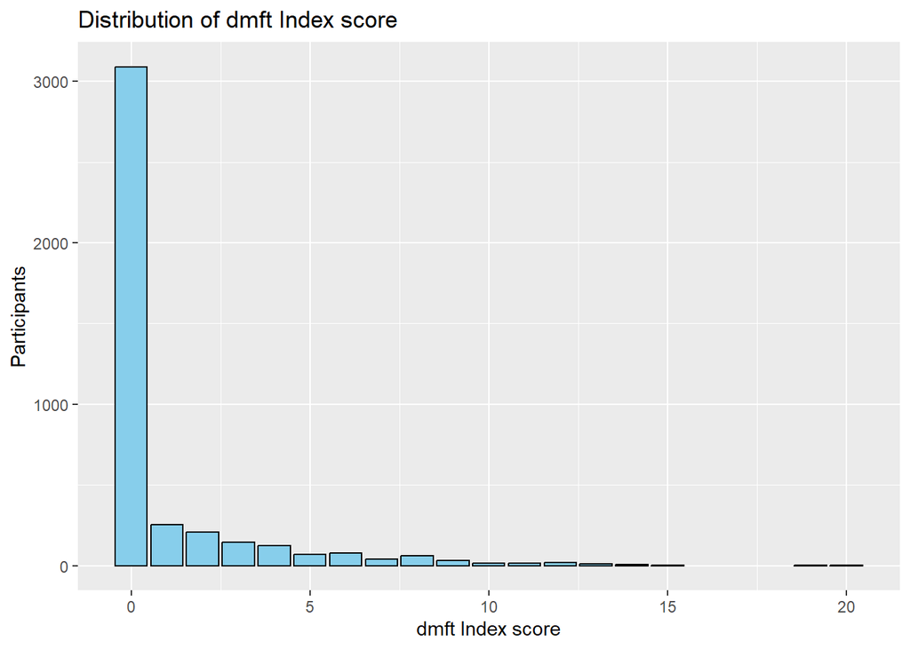

```r
#See distribution
ggplot(data = examen13, aes(x = dmft)) +
  geom_bar(fill = "skyblue", color = "black") +
  labs(x = "dmft Index score", y = "Participants", title = "Distribution of dmft Index score")
```

### Children 5 years old

dmft can take into account the first permanent molar. So the maximum value can be up to 24.

```r
examen5 <- examen5completa %>%
  dplyr::select(MB_208, MB_305A, MB_305B, MB_305C, MB_305D, MB_305E, MB_305F, MB_305G, MB_305H, MB_305I, MB_305J, MB_305K, MB_305L, MB_307A, MB_307B, MB_307C, MB_307D, MB_307E, MB_307F, MB_307G, MB_307H, MB_307I, MB_307J, MB_307K, MB_307L, ID_HOGAR, ID_PERSONA)

glimpse(examen5)
```

```
## Rows: 2,277
## Columns: 27
## $ MB_208     <dbl> 1, 1, 1, 1, 1, 1, 1, 1, 1, 1, 1, 1, 1, 1, 1, 1, 1, 1, 1, 1,…
## $ MB_305A    <dbl> 8, 8, 8, 0, 8, 8, 8, 8, 8, 8, 8, 8, 8, 8, 8, 8, 8, 8, 8, 8,…
## $ MB_305B    <chr> "A", "A", "D", "F", "A", "B", "A", "A", "B", "A", "A", "F",…
## $ MB_305C    <chr> "A", "A", "A", "F", "A", "B", "A", "A", "C", "A", "A", "F",…
## $ MB_305D    <chr> "A", "A", "A", "A", "A", "A", "A", "A", "A", "A", "A", "B",…
## $ MB_305E    <chr> "A", "A", "A", "A", "A", "B", "A", "A", "B", "A", "B", "A",…
## $ MB_305F    <chr> "A", "A", "A", "A", "A", "B", "B", "A", "B", "A", "B", "A",…
## $ MB_305G    <chr> "A", "A", "A", "A", "A", "B", "A", "A", "B", "A", "B", "B",…
## $ MB_305H    <chr> "A", "A", "A", "A", "A", "A", "A", "A", "B", "A", "B", "A",…
## $ MB_305I    <chr> "A", "A", "A", "A", "A", "A", "A", "A", "A", "A", "A", "A",…
## $ MB_305J    <chr> "A", "A", "A", "F", "A", "B", "A", "A", "D", "A", "A", "A",…
## $ MB_305K    <chr> "A", "A", "D", "F", "A", "A", "A", "A", "A", "A", "A", "A",…
## $ MB_305L    <dbl> 8, 8, 8, 0, 8, 8, 8, 8, 8, 8, 8, 8, 8, 8, 8, 8, 8, 8, 8, 8,…
## $ MB_307A    <dbl> 8, 8, 8, 0, 8, 8, 8, 8, 0, 8, 8, 8, 8, 8, 8, 8, 8, 8, 8, 8,…
## $ MB_307B    <chr> "A", "A", "F", "F", "A", "B", "A", "A", "A", "A", "B", "D",…
## $ MB_307C    <chr> "A", "A", "F", "F", "A", "B", "A", "A", "D", "A", "A", "A",…
## $ MB_307D    <chr> "A", "A", "A", "A", "A", "B", "A", "A", "A", "A", "A", "A",…
## $ MB_307E    <chr> "A", "A", "A", "A", "A", "A", "A", "A", "A", "A", "A", "A",…
## $ MB_307F    <chr> "A", "A", "A", "0", "A", "A", "A", "A", "A", "A", "A", "A",…
## $ MB_307G    <chr> "A", "A", "A", "0", "A", "A", "A", "A", "A", "A", "A", "A",…
## $ MB_307H    <chr> "A", "A", "A", "A", "A", "A", "A", "A", "A", "A", "A", "A",…
## $ MB_307I    <chr> "A", "A", "A", "A", "A", "B", "A", "A", "A", "A", "A", "A",…
## $ MB_307J    <chr> "A", "A", "F", "F", "A", "B", "A", "A", "A", "A", "A", "F",…
## $ MB_307K    <chr> "A", "F", "F", "F", "A", "A", "A", "A", "A", "A", "A", "D",…
## $ MB_307L    <dbl> 8, 8, 8, 0, 8, 8, 8, 8, 8, 8, 8, 8, 8, 8, 8, 8, 8, 8, 8, 8,…
## $ ID_HOGAR   <dbl> 100501, 106801, 107101, 201301, 2208101, 2211301, 2302101, …
## $ ID_PERSONA <dbl> 10050103, 10680106, 10710103, 20130104, 220810106, 22113010…
```

```r
#Assign a value to 1 to the following numbers: 1, 2, 3, 4, 7
examen5 <- examen5 %>%
  mutate(
    across(
      starts_with("MB_3"),
      ~case_when(
        str_detect(., "^[12347]$|^[BCDEG]$") ~ 1,
        TRUE ~ 0
      )))

#create variable dmft
examen5 <- examen5 %>%
  mutate(dmft = rowSums(across(starts_with("MB_3"), ~. > 0))) %>%
  dplyr::select(-starts_with("MB_3"))

summary(examen5$dmft)
```

```
##    Min. 1st Qu.  Median    Mean 3rd Qu.    Max.
##   0.000   0.000   1.000   2.747   4.000  20.000
```

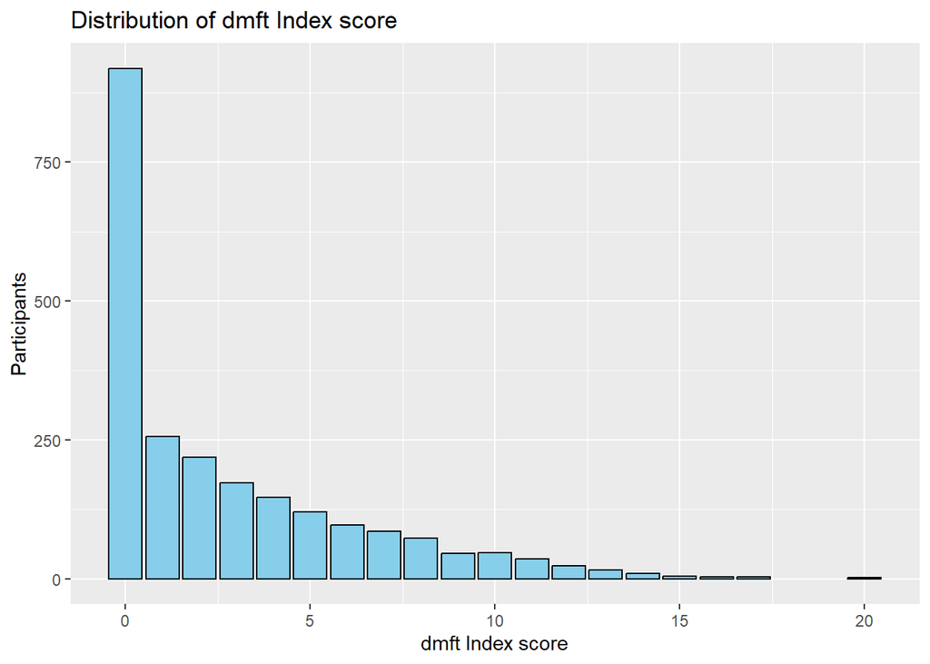

```r
#See distribution
ggplot(data = examen5, aes(x = dmft)) +
  geom_bar(fill = "skyblue", color = "black") +
  labs(x = "dmft Index score", y = "Participants", title = "Distribution of dmft Index score")
```

Merge datasets:

```r
ensab <- ninos %>%
  left_join(examen13, by = "ID_PERSONA") %>%
  left_join(examen5, by = "ID_PERSONA") %>%
  mutate(dmft = coalesce(dmft.x, dmft.y),
         ID_HOGAR = coalesce(ID_HOGAR.x, ID_HOGAR.y)) %>%
  dplyr::select(-ID_HOGAR.x, -ID_HOGAR.y, -dmft.x, -dmft.y)

#Missing data

ensab %>%
  filter(MA_208 == 2 | MB_208 == 2) %>%
  count()
```

```
## # A tibble: 1 × 1
##       n
##   <int>
## 1     3
```

```r
ensab <- ensab %>%
  filter(MA_208 == 1 | MB_208 == 1) %>%
  dplyr::select(-MB_208, -MA_208)

#only  3 children did not have the clinical examination portion. We'll exclude them. Now the sample size is 6443 children.
```

## Account for survey design and weights

```r
survensab <- svydesign(ids = ~1, data = ensab, weights = ~Fex_fin)
summary(survensab)
```

```
## Independent Sampling design (with replacement)
## svydesign(ids = ~1, data = ensab, weights = ~Fex_fin)
## Probabilities:
##      Min.   1st Qu.    Median      Mean   3rd Qu.      Max.
## 0.0001077 0.0021098 0.0040716 0.0198193 0.0078863 1.0000000
## Data variables:
##  [1] "MPIO"       "DPTO"       "M3_100C"    "M3_113E"    "M3_113F"
##  [6] "M3_119"     "M3_205"     "M3_206A"    "M3_206B"    "M3_207"
## [11] "M3_208"     "M3_209"     "M3_210"     "M3_213"     "M3_214"
## [16] "M3_218"     "M3_224"     "M3_225"     "M3_226"     "M3_227"
## [21] "M3_227A"    "M3_227B"    "M3_227C"    "M3_227D"    "M3_227E"
## [26] "M3_227F"    "M3_227G"    "M3_227CU"   "Clase"      "Region"
## [31] "Subreg"     "Estrato"    "Fex_fin"    "Sexo"       "Zona"
## [36] "EST_SE_2"   "FRACCION"   "REGIMEN"    "ID_PERSONA" "ID_HOGAR"
## [41] "dmft"
```

```r
glimpse(ensab)
```

```
## Rows: 6,443
## Columns: 41
## $ MPIO       <chr> "MEDELLIN", "MEDELLIN", "MEDELLIN", "MEDELLIN", "MEDELLIN",…
## $ DPTO       <chr> "ANTIOQUIA", "ANTIOQUIA", "ANTIOQUIA", "ANTIOQUIA", "ANTIOQ…
## $ M3_100C    <dbl> 5, 3, 5, 5, 1, 5, 3, 5, 1, 5, 5, 1, 3, 3, 1, 1, 1, 5, 5, 1,…
## $ M3_113E    <chr> "NULL", "NULL", "NULL", "NULL", "NULL", "NULL", "6", "NULL"…
## $ M3_113F    <chr> "NULL", "NULL", "NULL", "NULL", "NULL", "NULL", "6", "NULL"…
## $ M3_119     <dbl> 3, 2, 2, 2, 3, 1, 8, 2, 3, 2, 2, 1, 3, 3, 3, 3, 2, 2, 3, 2,…
## $ M3_205     <dbl> 1, 1, 1, 1, 2, 1, 1, 1, 2, 2, 2, 2, 1, 2, 2, 2, 2, 1, 1, 2,…
## $ M3_206A    <chr> "3", "36", "36", "24", "NULL", "4", "2", "2", "NULL", "NULL…
## $ M3_206B    <chr> "2", "1", "1", "1", "NULL", "2", "2", "2", "NULL", "NULL", …
## $ M3_207     <chr> "1", "1", "1", "1", "NULL", "1", "1", "1", "NULL", "NULL", …
## $ M3_208     <chr> "1", "1", "3", "3", "NULL", "1", "2", "1", "NULL", "NULL", …
## $ M3_209     <chr> "3", "3", "3", "3", "NULL", "3", "3", "3", "NULL", "NULL", …
## $ M3_210     <chr> "2", "2", "2", "2", "NULL", "2", "2", "2", "NULL", "NULL", …
```

[output cut: 28 more lines]

#Key variables

Age: M3_100C

It really is categorical and not continuous.

```r
glimpse(ensab$M3_100C)
```

```
##  num [1:6443] 5 3 5 5 1 5 3 5 1 5 ...
```

```r
summary(ensab$M3_100C)
```

```
##    Min. 1st Qu.  Median    Mean 3rd Qu.    Max.
##   1.000   1.000   3.000   3.058   5.000   5.000
```

```r
#rename M2_100C to age
ensab <- ensab %>%
  rename(age = M3_100C) %>%
  mutate(age = factor(age,
                      levels = c(1, 3, 5),
                      labels = c("1", "3", "5")))

summary(ensab$age)
```

```
##    1    3    5
## 2088 2079 2276
```

## Posible exposures

### Age of first dental visit (agefdv)

It is composed of: - M3_206A: numeric - M3_206B: 1: months, 2: years

Take into account M3_205: have they ever had an appointment with a dentist?  
1: yes, 2: no, 3: doesn’t know

Combine 206A and 205 to categorize.

```r
#Turn M3_206A into a numeric variable
ensab$M3_206A <- as.numeric(ensab$M3_206A)
summary(ensab$M3_206A)
```

```
##    Min. 1st Qu.  Median    Mean 3rd Qu.    Max.    NA's
##    1.00    3.00   12.00   14.85   24.00   70.00    2648
```

```r
ensab %>%
  filter(M3_205 == 2 | M3_205 == 3) %>%
  count()
```

```
## # A tibble: 1 × 1
##       n
##   <int>
## 1  2648
```

```r
#2648: coincides with the number of NAs

ensab %>%
  filter(M3_205 == 3) %>%
  count()
```

```
## # A tibble: 1 × 1
##       n
##   <int>
## 1    46
```

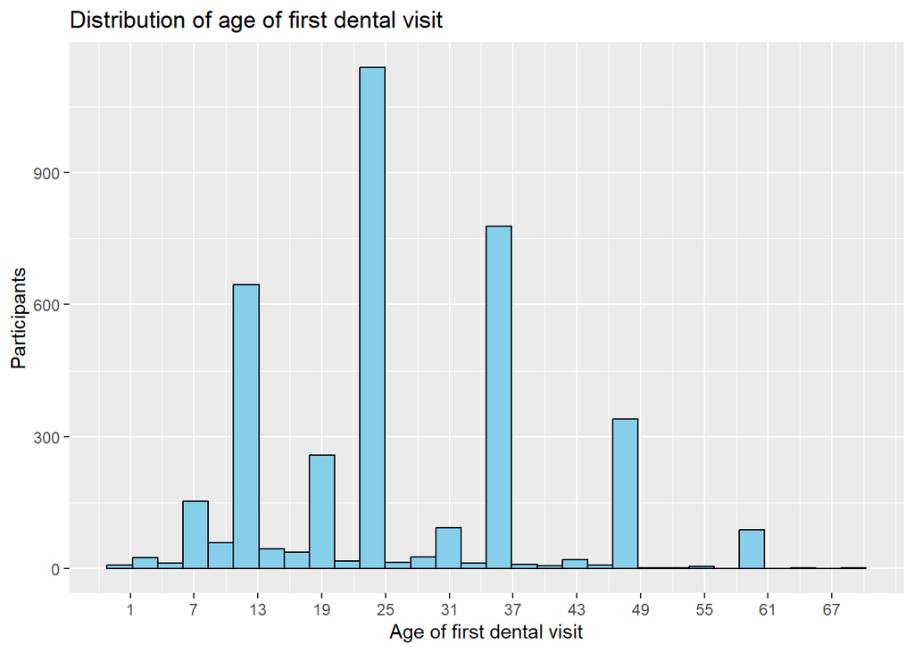

```r
#only 46 participants have missing values for M3_205

#multiply values in the filtered rows by 12 and categorize
ensab <- ensab %>%
  mutate(agefdv = if_else(M3_206B == 2, M3_206A * 12, M3_206A))

ggplot(ensab, aes(x = agefdv)) +
  geom_histogram(fill = "skyblue", color = "black") +
  scale_x_continuous(breaks = seq(min(ensab$agefdv, na.rm = TRUE), max(ensab$agefdv, na.rm = TRUE), by = 6)) +
  labs(x = "Age of first dental visit", y = "Participants", title = "Distribution of age of first dental visit")
```

```r
# can do bins 0-6, 7-12, 13-24, 25-36, 37-48, 49-72, or just divide into 3.

ensab <- ensab %>%
  mutate(agefdv = case_when(
    M3_205 == 3 ~ NA_real_,
    M3_205 == 2 ~ 0,
    agefdv <= 12 ~ 1,
    agefdv > 12 ~ 2,
    TRUE ~ agefdv)) %>%
  mutate(agefdv = factor(agefdv,
                         levels = c(0, 1, 2),
                         labels = c("Never", "0-12", "13+")))

summary(ensab$agefdv)
```

```
## Never  0-12   13+  NA's
##  2602   883  2912    46
```

```r
ensab <- ensab %>%
  dplyr::select(-M3_206B, -M3_206A)
```

### Reason for last consultation (reason)

M3_209: 1: por una urgencia 2: para un tratamiento 3: por revision/prevencion 4: certificado odontologico

M207 Is important: when was the last appointment of the child with the dentist? 1: less than a year ago 2: between 1-2 years 3: more than 3 years 4: does not remember (NA)

```r
ensab %>%
  filter(M3_207 == 4) %>%
  count()
```

```
## # A tibble: 1 × 1
##       n
##   <int>
## 1    45
```

```r
#45 NAs to be expected in M3_209

ensab <- ensab %>%
  mutate(reason = factor(M3_209,
    levels = c(1, 2, 3, 4),
    labels = c("Emergency", "Treatment", "Prevention", "Certificate")))

summary(ensab$reason)
```

```
##   Emergency   Treatment  Prevention Certificate        NA's
##         177         787        2272         559        2648
```

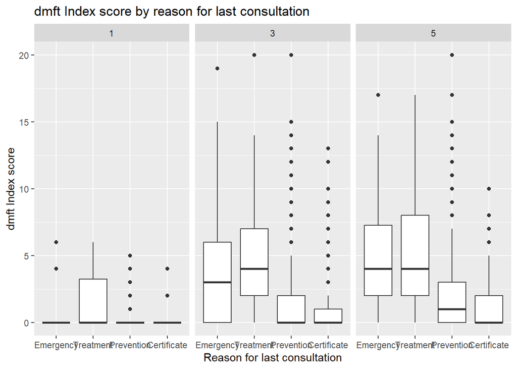

```r
#2648 NAs

ensab %>%
  filter(!is.na(reason)) %>%
  ggplot(aes(x = reason, y = dmft)) +
  geom_boxplot() +
  facet_wrap(~age) +
  labs(x = "Reason for last consultation", y = "dmft Index score", title = "dmft Index score by reason for last consultation")
```

```r
#We will bring emergency and treatment into one category, and prevention and certificate into another

ensab <- ensab %>%
  mutate(
    reason_grouped = case_when(
      M3_209 %in% c(1, 2) ~ 1,  # Group Emergency and Treatment into 1
      M3_209 %in% c(3, 4) ~ 2   # Group Prevention and Certificate into 2
    ),
    reason_grouped = factor(reason_grouped, levels = c(1, 2), labels = c("Emergency/Treatment", "Prevention/Certificate"))
  )

summary(ensab$reason_grouped)
```

```
##    Emergency/Treatment Prevention/Certificate                   NA's
##                    964                   2831                   2648
```

### Age of start of dental hygiene = agehyg

M3_213: units are months, continuous 91: doesn’t know 92: has never gotten dental hygiene done

```r
ensab %>%
  filter(M3_213 == 91 | M3_213 == 92) %>%
  count()
```

```
## # A tibble: 1 × 1
##       n
##   <int>
## 1   385
```

```r
#385

ensab %>%
  filter(M3_213 == 91) %>%
  count()
```

```
## # A tibble: 1 × 1
##       n
##   <int>
## 1   153
```

```r
#NA

ensab %>%
  group_by(age) %>%
  filter(M3_213 == 92) %>%
  count()
```

```
## # A tibble: 3 × 2
## # Groups:   age [3]
##   age       n
##   <fct> <int>
## 1 1       226
## 2 3         4
## 3 5         2
```

```r
#226 children at 1 years old have never gotten dental hygiene done, 4 at age 3 and 2 at age 5

glimpse(ensab$M3_213)
```

```
##  num [1:6443] 3 6 7 3 3 3 3 3 12 30 ...
```

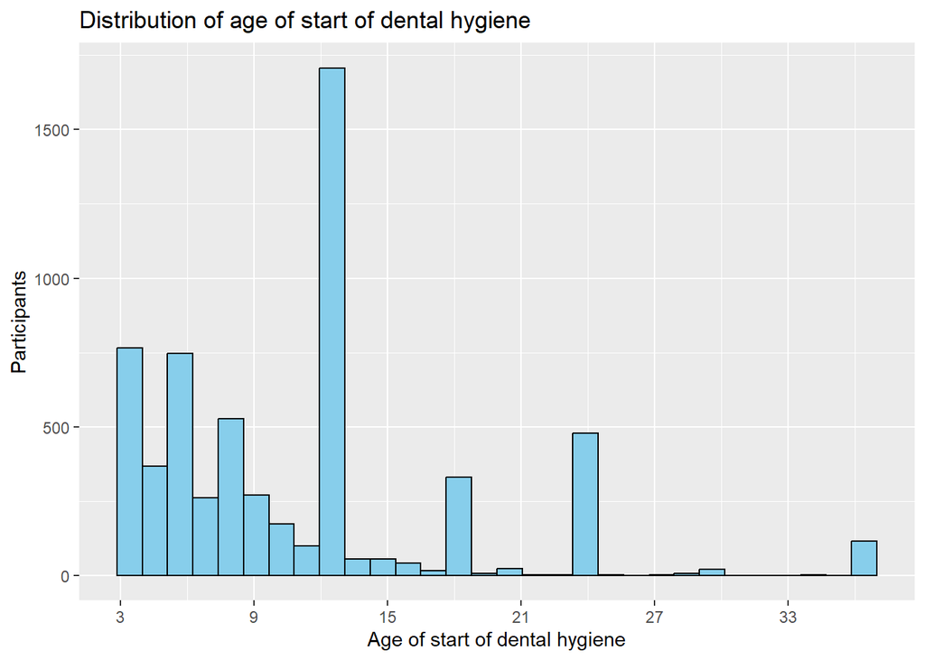

```r
#create distribution
ensab %>%
  filter(!(M3_213 %in% c(91, 92))) %>%
  ggplot(aes(x = M3_213)) +
  geom_histogram(fill = "skyblue", color = "black") +
  scale_x_continuous(breaks = seq(min(ensab$M3_213, na.rm = TRUE), max(ensab$M3_213, na.rm = TRUE), by = 6)) +
  labs(x = "Age of start of dental hygiene", y = "Participants", title = "Distribution of age of start of dental hygiene")
```

```r
#max value of M3_213 without 91 or 92 using summary only for M3_213

ensab %>%
  filter(!(M3_213 %in% c(91, 92))) %>%
  summary()
```

```
##      MPIO               DPTO           age        M3_113E
##  Length:6058        Length:6058        1:1815   Length:6058
##  Class :character   Class :character   3:2035   Class :character
##  Mode  :character   Mode  :character   5:2208   Mode  :character
##
##
##
##    M3_113F              M3_119          M3_205         M3_207
##  Length:6058        Min.   :1.000   Min.   :1.000   Length:6058
##  Class :character   1st Qu.:2.000   1st Qu.:1.000   Class :character
##  Mode  :character   Median :2.000   Median :1.000   Mode  :character
##                     Mean   :2.568   Mean   :1.394
##                     3rd Qu.:3.000   3rd Qu.:2.000
##                     Max.   :8.000   Max.   :3.000
##     M3_208             M3_209             M3_210              M3_213
##  Length:6058        Length:6058        Length:6058        Min.   : 3.00
##  Class :character   Class :character   Class :character   1st Qu.: 6.00
##  Mode  :character   Mode  :character   Mode  :character   Median :10.00
##                                                           Mean   :10.84
##                                                           3rd Qu.:12.00
##                                                           Max.   :36.00
##     M3_214             M3_218              M3_224          M3_225
##  Length:6058        Length:6058        Min.   : 0.00   Min.   :1.000
##  Class :character   Class :character   1st Qu.: 4.00   1st Qu.:1.000
##  Mode  :character   Mode  :character   Median : 6.00   Median :2.000
##                                        Mean   :11.31   Mean   :1.708
##                                        3rd Qu.: 7.00   3rd Qu.:2.000
##                                        Max.   :92.00   Max.   :2.000
##     M3_226             M3_227            M3_227A            M3_227B
##  Length:6058        Length:6058        Length:6058        Length:6058
##  Class :character   Class :character   Class :character   Class :character
##  Mode  :character   Mode  :character   Mode  :character   Mode  :character
##
##
##
##    M3_227C            M3_227D            M3_227E            M3_227F
##  Length:6058        Length:6058        Length:6058        Length:6058
##  Class :character   Class :character   Class :character   Class :character
##  Mode  :character   Mode  :character   Mode  :character   Mode  :character
##
```

[output cut: 22 more lines]

```
##  Max.   :2.000   Max.   :4.000   Max.   :13.000   Max.   :4.000
##    ID_PERSONA           ID_HOGAR              dmft          agefdv
##  Min.   :1.005e+07   Min.   :1.005e+05   Min.   : 0.000   Never:2314
##  1st Qu.:6.708e+10   1st Qu.:6.708e+08   1st Qu.: 0.000   0-12 : 855
##  Median :3.444e+11   Median :3.444e+09   Median : 0.000   13+  :2853
##  Mean   :4.021e+11   Mean   :4.021e+09   Mean   : 1.709   NA's :  36
##  3rd Qu.:6.893e+11   3rd Qu.:6.893e+09   3rd Qu.: 2.000
##  Max.   :1.019e+12   Max.   :1.019e+10   Max.   :20.000
##          reason                    reason_grouped
##  Emergency  : 173   Emergency/Treatment   : 943
##  Treatment  : 770   Prevention/Certificate:2765
##  Prevention :2219   NA's                  :2350
##  Certificate: 546
##  NA's       :2350
##
```

```r
#Categorize into: never, 0-6 months, more than 6 months

ensab <- ensab %>%
  mutate(agehyg = case_when(
    M3_213 == 91 ~ NA_real_,
    M3_213 <= 6 ~ 1,
    M3_213 > 6 & M3_213 <= 12 ~ 2,
    M3_213 > 12 & M3_213 <= 36 ~ 3,
    M3_213 == 92 ~ 4
  )) %>%
  mutate(agehyg = factor(agehyg,
                        levels = c(1, 2, 3, 4),
                        labels = c( "0-6 months", "6-12 months", "+12 months", "Never")))

#Proportions

ensab %>%
  group_by(age, agehyg) %>%
  count() %>%
  group_by(age) %>%
  mutate(prop = n / sum(n) * 100)
```

```
## # A tibble: 15 × 4
## # Groups:   age [3]
##    age   agehyg          n    prop
##    <fct> <fct>       <int>   <dbl>
##  1 1     0-6 months    686 32.9
##  2 1     6-12 months   970 46.5
##  3 1     +12 months    159  7.61
##  4 1     Never         226 10.8
##  5 1     <NA>           47  2.25
##  6 3     0-6 months    603 29.0
##  7 3     6-12 months   951 45.7
##  8 3     +12 months    481 23.1
##  9 3     Never           4  0.192
## 10 3     <NA>           40  1.92
## 11 5     0-6 months    587 25.8
## 12 5     6-12 months  1078 47.4
## 13 5     +12 months    543 23.9
## 14 5     Never           2  0.0879
## 15 5     <NA>           66  2.90
```

### Information on toothpaste for the child (tp_info)

```r
glimpse(ensab$M3_218)
```

```
##  chr [1:6443] "1" "1" "1" "2" "2" "2" "1" "1" "2" "1" "2" "2" "2" "1" "1" ...
```

```r
ensab <- ensab %>%
  mutate(tp_info = case_when(
    M3_218 == 3 ~ NA,
    TRUE ~ M3_218)) %>%
  mutate(tp_info = factor(tp_info,
                          levels = c(1, 2),
                          labels = c("Yes", "No")))

summary(ensab$tp_info)
```

```
##  Yes   No NA's
## 1591 4606  246
```

### Breastfeeding age in months

M3_224

91: Never 92: Doesn’t know (NA)

```r
glimpse(ensab$M3_224)
```

```
##  num [1:6443] 0 6 6 4 7 5 6 6 1 8 ...
```

```r
ensab %>%
  filter(M3_224 == 92) %>%
  count()
```

```
## # A tibble: 1 × 1
##       n
##   <int>
## 1    98
```

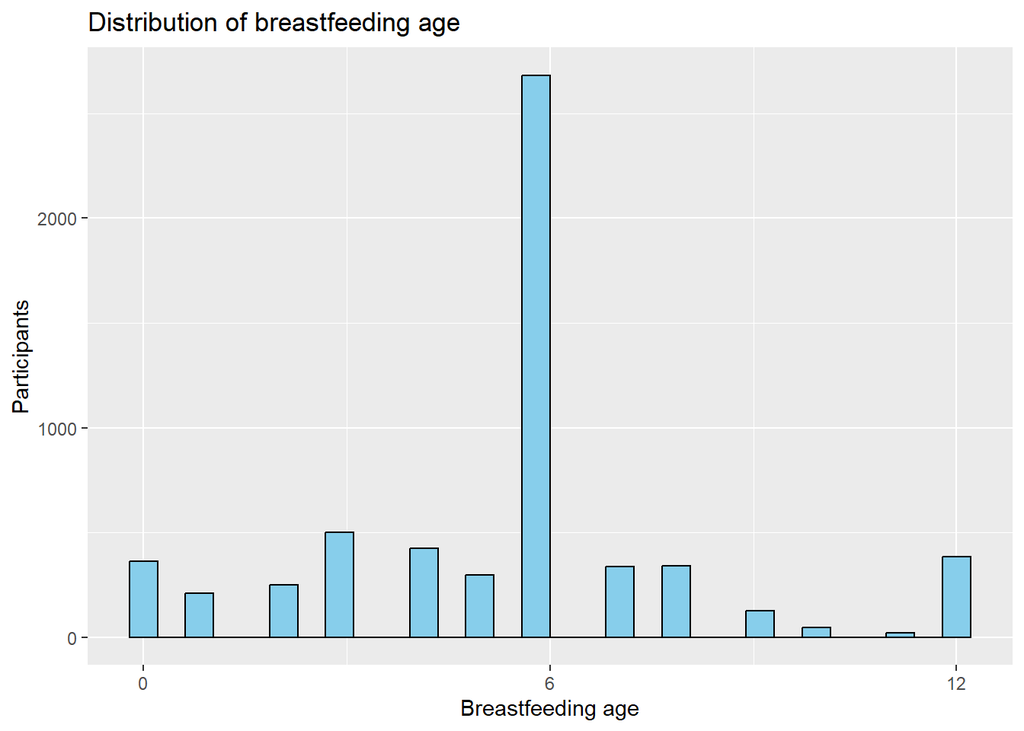

```r
#98 NAs

ensab <- ensab %>%
  mutate(bf = case_when(
    M3_224 == 92 ~ NA,
    TRUE ~ M3_224))

#distribution of bf

ensab %>%
  filter(!(bf == 91)) %>%
  ggplot(aes(x = bf)) +
  geom_histogram(fill = "skyblue", color = "black") +
  scale_x_continuous(breaks = seq(min(ensab$bf, na.rm = TRUE), max(ensab$bf, na.rm = TRUE), by = 6)) +
  labs(x = "Breastfeeding age", y = "Participants", title = "Distribution of breastfeeding age")
```

```r
ensab %>%
  filter(!(bf == 91)) %>%
  summary()
```

```
##      MPIO               DPTO           age        M3_113E
##  Length:5976        Length:5976        1:1968   Length:5976
##  Class :character   Class :character   3:1916   Class :character
##  Mode  :character   Mode  :character   5:2092   Mode  :character
##
##
##
##    M3_113F              M3_119          M3_205         M3_207
##  Length:5976        Min.   :1.000   Min.   :1.000   Length:5976
##  Class :character   1st Qu.:2.000   1st Qu.:1.000   Class :character
##  Mode  :character   Median :2.000   Median :1.000   Mode  :character
##                     Mean   :2.569   Mean   :1.416
##                     3rd Qu.:3.000   3rd Qu.:2.000
##                     Max.   :8.000   Max.   :3.000
##     M3_208             M3_209             M3_210              M3_213
##  Length:5976        Length:5976        Length:5976        Min.   : 3.00
##  Class :character   Class :character   Class :character   1st Qu.: 6.00
##  Mode  :character   Mode  :character   Mode  :character   Median :11.00
##                                                           Mean   :15.25
##                                                           3rd Qu.:12.00
##                                                           Max.   :92.00
##     M3_214             M3_218              M3_224           M3_225
##  Length:5976        Length:5976        Min.   : 0.000   Min.   :1.0
##  Class :character   Class :character   1st Qu.: 4.000   1st Qu.:1.0
##  Mode  :character   Mode  :character   Median : 6.000   Median :2.0
##                                        Mean   : 5.522   Mean   :1.7
##                                        3rd Qu.: 6.000   3rd Qu.:2.0
##                                        Max.   :12.000   Max.   :2.0
##     M3_226             M3_227            M3_227A            M3_227B
##  Length:5976        Length:5976        Length:5976        Length:5976
##  Class :character   Class :character   Class :character   Class :character
##  Mode  :character   Mode  :character   Mode  :character   Mode  :character
##
##
##
##    M3_227C            M3_227D            M3_227E            M3_227F
##  Length:5976        Length:5976        Length:5976        Length:5976
##  Class :character   Class :character   Class :character   Class :character
##  Mode  :character   Mode  :character   Mode  :character   Mode  :character
##
```

[output cut: 29 more lines]

```
##  Max.   :1.019e+12   Max.   :1.019e+10   Max.   :20.00
##          reason                    reason_grouped         agehyg
##  Emergency  : 168   Emergency/Treatment   : 906   0-6 months :1736
##  Treatment  : 738   Prevention/Certificate:2620   6-12 months:2825
##  Prevention :2096   NA's                  :2450   +12 months :1088
##  Certificate: 524                                 Never      : 219
##  NA's       :2450                                 NA's       : 108
##
##  tp_info           bf
##  Yes :1495   Min.   : 0.000
##  No  :4249   1st Qu.: 4.000
##  NA's: 232   Median : 6.000
##              Mean   : 5.522
##              3rd Qu.: 6.000
##              Max.   :12.000
```

```r
#12 seems like the maximum value

#Categorize into: never, 0-6 months, more than 6 months

ensab <- ensab %>%
  mutate(bf = case_when(
    bf == 91 ~ 1,
    bf <= 6 ~ 2,
    bf > 6 ~ 3,
  )) %>%
  mutate(bf = factor(bf,
                     levels = c(1, 2, 3),
                     labels = c("Never", "0-6 months", "More than 6 months")))

summary(ensab$bf)
```

```
##              Never         0-6 months More than 6 months               NA's
##                369               4720               1256                 98
```

### Bottle use: M3_225, M3_226, M3_227, M3_227A-M3_227CU, and M3_228

For M3_227, we want to include: - D: sugared drinks - F: sodas - G: others, explore which ones and if they are cariogenic or not Exclude A (mothers milk), B (formula), C (other types of milk). E is unsure if it includes cariogenic drinks

```r
#Bottle use at the moment of the survey

ensab %>%
  filter(M3_225 == 2) %>%
  count()
```

```
## # A tibble: 1 × 1
##       n
##   <int>
## 1  4487
```

```r
#4487 don't use the bottle currently

glimpse(ensab$age)
```

```
##  Factor w/ 3 levels "1","3","5": 3 2 3 3 1 3 2 3 1 3 ...
```

```r
#of those that do, what age are they?
ensab %>%
  filter(M3_225 == 1) %>%
  group_by(age) %>%
  count()
```

```
## # A tibble: 3 × 2
## # Groups:   age [3]
##   age       n
##   <fct> <int>
## 1 1      1242
## 2 3       541
## 3 5       173
```

```r
#225 and 226 include past and current use, might be a problem to create variable of age of bottle use. It might be more important what is in the bottle.

#M3_227: what do they put in the bottle. 0: no aplica, 1: aplica

glimpse(ensab$M3_227CU)
```

```
##  chr [1:6443] NA NA NA NA NA NA NA NA NA NA NA NA NA NA NA NA NA NA NA NA ...
```

```r
ensab %>%
  filter(M3_227G == 1) %>%
  select(M3_227G, M3_227CU, ID_PERSONA) %>% #order M3_227CU in alphabetical order
  distinct(M3_227CU)
```

```
## # A tibble: 260 × 1
##    M3_227CU
##    <chr>
##  1 PAPILLA
##  2 COLADAS
##  3 JUGOS NATURALES
##  4 YOGURT
##  5 ZB VITAMIII
##  6 AVENA
##  7 NESTUN ZVEC KOLA
##  8 COLADAS AGUADEPANELA
##  9 COLADAS BIENESTARINA
## 10 NESTUN
## # ℹ 250 more rows
```

## Possible confounders or EMM

Sex: Sexo

Couldn’t find the codification in the codebook so I had to guess.

```r
glimpse(ensab$Sexo)
```

```
##  num [1:6443] 2 2 1 1 2 2 1 1 2 1 ...
```

```r
ensab <- ensab %>%
  mutate(sex = factor(Sexo,
                         levels = c(1, 2),
                         labels = c("Masculine", "Feminine")))

summary(ensab$sex)
```

```
## Masculine  Feminine
##      3340      3103
```

Socioeconomic status: EST_SE_2

```r
glimpse(ensab$EST_SE_2)
```

```
##  num [1:6443] 2 1 1 1 2 1 2 2 2 2 ...
```

```r
ensab <- ensab %>%
  mutate(ses = factor(EST_SE_2,
                           levels = c(1, 2, 3, 4),
                           labels = c("Low low", "Low", "Middle low", "Middle to high")))

summary(ensab$ses)
```

```
##        Low low            Low     Middle low Middle to high
##           2652           2686           1010             95
```

Income: M3_119

NMW: national minimum wage (salario minimo legal vigente)

```r
glimpse(ensab$M3_119)
```

```
##  num [1:6443] 3 2 2 2 3 1 8 2 3 2 ...
```

```r
#8 are NAs
ensab %>%
  filter(M3_119 == 8) %>%
  count()
```

```
## # A tibble: 1 × 1
##       n
##   <int>
## 1    95
```

```r
#transform 7 unemployed into 0

ensab <- ensab %>%
  mutate(income = case_when(
    M3_119 == 8 ~ NA,
    M3_119 == 7 ~ 0,
    TRUE ~ M3_119)) %>%
  mutate(income = factor(income,
                         levels = c(0, 1, 2, 3, 4, 5, 6),
                         labels = c("Unemployed", "Less than half NMW", "Half - 1 NMW", "1-2 NMW", "2-3 NMW", "3-4 NMW", "More than 4 NMW")))

summary(ensab$income)
```

```
##         Unemployed Less than half NMW       Half - 1 NMW            1-2 NMW
##                 86               1009               2524               2091
##            2-3 NMW            3-4 NMW    More than 4 NMW               NA's
##                403                112                123                 95
```

Health insurance coverage/scheme:

Chose REGIMEN over M3_113E because it has less categories plus no missing values, and it reflects the insurance status of the child and not the main provider.

```r
glimpse(ensab$REGIMEN)
```

```
##  num [1:6443] 4 1 2 2 2 2 2 2 1 2 ...
```

```r
#counting NAs in M3_113E

ensab %>%
  filter(M3_113E == 6) %>%
  count()
```

```
## # A tibble: 1 × 1
##       n
##   <int>
## 1    82
```

```r
ensab <- ensab %>%
  mutate(insurance = case_when(
    REGIMEN == 4 ~ 0,
    TRUE ~ REGIMEN)) %>%
  mutate(insurance = factor(insurance,
                           levels = c(0, 1, 2, 3),
                           labels = c("Uninsured", "Contributory", "Subsidized", "Other")))

summary(ensab$insurance)
```

```
##    Uninsured Contributory   Subsidized        Other
##          439         2241         3488          275
```

Region

```r
glimpse(ensab$Region)
```

```
##  num [1:6443] 3 3 3 3 3 3 3 3 3 3 ...
```

```r
ensab <- ensab %>%
  mutate(region = factor(Region,
                         levels = c(1, 2, 3, 4, 5, 6),
                         labels = c("Atlantic", "Eastern", "Central", "Pacific", "Bogota", "Orinoquia - Amazonia")))

summary(ensab$region)
```

```
##             Atlantic              Eastern              Central
##                 1078                 1092                  982
##              Pacific               Bogota Orinoquia - Amazonia
##                  998                 1174                 1119
```

Urban vs rural: Zona

Will be named location Chose Zona over Clase because it has more universal categories (rural and urban), while Clase has categories according to the national census. However, it has more granularity and could be useful.

```r
glimpse(ensab$Zona)
```

```
##  num [1:6443] 1 1 1 1 1 1 1 1 1 1 ...
```

```r
ensab %>%
  group_by(Zona, .drop = FALSE) %>%
  count()
```

```
## # A tibble: 2 × 2
## # Groups:   Zona [2]
##    Zona     n
##   <dbl> <int>
## 1     1  5265
## 2     2  1178
```

```r
ensab <- ensab %>%
  mutate(location = factor(Zona,
                           levels = c(1, 2),
                           labels = c("Urban", "Rural")))

summary(ensab$location)
```

```
## Urban Rural
##  5265  1178
```

# Association between caries and possible exposures

## Relationship between age of start of dental hygiene and caries (dmft)

The hypothesis is that the later the start of dental hygiene, the higher the dmft index.

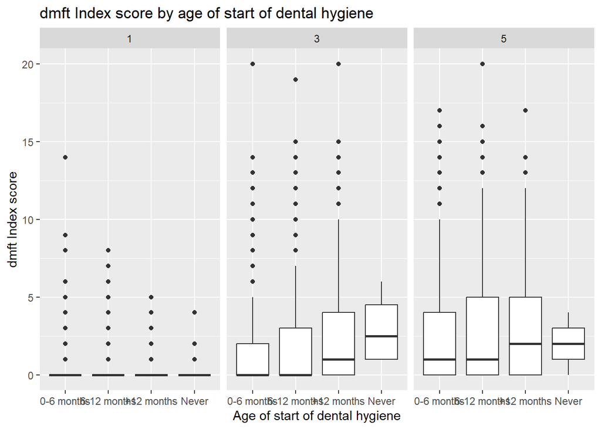

```r
#Relationship between age of start of dental hygiene and dmft

ensab %>%
  filter(!is.na(agehyg)) %>%
  ggplot(aes(x = agehyg, y = dmft)) +
  geom_boxplot() +
  facet_wrap(~age) +
  labs(x = "Age of start of dental hygiene", y = "dmft Index score", title = "dmft Index score by age of start of dental hygiene")
```

It looks like it is the case

### Regression

Negative binomial regression

```r
# Check for the whole sample first

modelhyg0 <- glm.nb(data = ensab, dmft ~ agehyg + age)
summary(modelhyg0)
```

```
##
## Call:
## glm.nb(formula = dmft ~ agehyg + age, data = ensab, init.theta = 0.3969842477,
##     link = log)
##
## Coefficients:
##                   Estimate Std. Error z value Pr(>|z|)
## (Intercept)       -1.83795    0.07620 -24.121  < 2e-16 ***
## agehyg6-12 months  0.12936    0.05790   2.234  0.02548 *
## agehyg+12 months   0.21380    0.06973   3.066  0.00217 **
## agehygNever       -0.75363    0.26046  -2.893  0.00381 **
## age3               2.38369    0.07795  30.580  < 2e-16 ***
## age5               2.73646    0.07687  35.597  < 2e-16 ***
## ---
## Signif. codes:  0 '***' 0.001 '**' 0.01 '*' 0.05 '.' 0.1 ' ' 1
##
## (Dispersion parameter for Negative Binomial(0.397) family taken to be 1)
##
##     Null deviance: 6657.1  on 6289  degrees of freedom
## Residual deviance: 4963.8  on 6284  degrees of freedom
##   (153 observations deleted due to missingness)
## AIC: 18440
##
## Number of Fisher Scoring iterations: 1
##
##
##               Theta:  0.3970
##           Std. Err.:  0.0130
##
##  2 x log-likelihood:  -18426.3530
```

```r
exp(modelhyg0$coefficients)
```

```
##       (Intercept) agehyg6-12 months  agehyg+12 months       agehygNever
##         0.1591427         1.1381000         1.2383756         0.4706561
##              age3              age5
##        10.8448863        15.4323006
```

```r
exp(confint(modelhyg0))
```

```
##                        2.5 %     97.5 %
## (Intercept)        0.1371012  0.1843657
## agehyg6-12 months  1.0151248  1.2751730
## agehyg+12 months   1.0797475  1.4209201
## agehygNever        0.2859051  0.7531682
## age3               9.3210458 12.6427348
## age5              13.2941079 17.9502453
```

```r
#multiple regression

modelhyg0m <- glm.nb(data = ensab, dmft ~ agehyg + age + sex + income + ses + insurance + region + location)
summary(modelhyg0m)
```

```
##
## Call:
## glm.nb(formula = dmft ~ agehyg + age + sex + income + ses + insurance +
##     region + location, data = ensab, init.theta = 0.4162714131,
##     link = log)
##
## Coefficients:
##                            Estimate Std. Error z value Pr(>|z|)
## (Intercept)                -1.90759    0.24134  -7.904 2.70e-15 ***
## agehyg6-12 months           0.05345    0.05889   0.908 0.364036
## agehyg+12 months            0.10873    0.07091   1.533 0.125210
## agehygNever                -0.82531    0.26121  -3.159 0.001580 **
## age3                        2.39038    0.07857  30.424  < 2e-16 ***
## age5                        2.78317    0.07760  35.864  < 2e-16 ***
## sexFeminine                -0.15559    0.04886  -3.184 0.001452 **
## incomeLess than half NMW   -0.07843    0.21302  -0.368 0.712746
## incomeHalf - 1 NMW         -0.15356    0.20687  -0.742 0.457916
## income1-2 NMW              -0.21666    0.20840  -1.040 0.298495
## income2-3 NMW              -0.16399    0.22884  -0.717 0.473605
## income3-4 NMW               0.01713    0.27837   0.062 0.950920
## incomeMore than 4 NMW      -0.34120    0.28492  -1.198 0.231104
## sesLow                      0.05259    0.06013   0.875 0.381824
## sesMiddle low              -0.28900    0.08414  -3.435 0.000594 ***
## sesMiddle to high          -0.59611    0.24672  -2.416 0.015685 *
## insuranceContributory      -0.13665    0.10761  -1.270 0.204114
## insuranceSubsidized         0.10293    0.10367   0.993 0.320757
## insuranceOther             -0.23286    0.15826  -1.471 0.141193
## regionEastern               0.52595    0.08798   5.978 2.26e-09 ***
## regionCentral               0.10712    0.09093   1.178 0.238787
## regionPacific               0.21365    0.08911   2.398 0.016504 *
## regionBogota                0.56959    0.08867   6.424 1.33e-10 ***
## regionOrinoquia - Amazonia  0.32961    0.08511   3.873 0.000108 ***
## locationRural               0.22986    0.06872   3.345 0.000824 ***
## ---
## Signif. codes:  0 '***' 0.001 '**' 0.01 '*' 0.05 '.' 0.1 ' ' 1
##
## (Dispersion parameter for Negative Binomial(0.4163) family taken to be 1)
##
##     Null deviance: 6765.5  on 6207  degrees of freedom
## Residual deviance: 4894.4  on 6183  degrees of freedom
##   (235 observations deleted due to missingness)
## AIC: 18122
##
## Number of Fisher Scoring iterations: 1
##
##
##               Theta:  0.4163
##           Std. Err.:  0.0139
##
##  2 x log-likelihood:  -18070.2270
```

```r
exp(modelhyg0m$coefficients)
```

```
##                (Intercept)          agehyg6-12 months
##                  0.1484381                  1.0549091
##           agehyg+12 months                agehygNever
##                  1.1148620                  0.4381007
##                       age3                       age5
##                 10.9176374                 16.1702188
##                sexFeminine   incomeLess than half NMW
##                  0.8559115                  0.9245673
##         incomeHalf - 1 NMW              income1-2 NMW
##                  0.8576500                  0.8051998
##              income2-3 NMW              income3-4 NMW
##                  0.8487468                  1.0172813
##      incomeMore than 4 NMW                     sesLow
##                  0.7109163                  1.0539925
##              sesMiddle low          sesMiddle to high
##                  0.7490151                  0.5509518
##      insuranceContributory        insuranceSubsidized
##                  0.8722728                  1.1084167
##             insuranceOther              regionEastern
##                  0.7922618                  1.6920612
##              regionCentral              regionPacific
##                  1.1130689                  1.2381937
##               regionBogota regionOrinoquia - Amazonia
##                  1.7675455                  1.3904213
##              locationRural
##                  1.2584212
```

```r
exp(confint(modelhyg0m))
```

```
##                                  2.5 %     97.5 %
## (Intercept)                 0.09363885  0.2401362
## agehyg6-12 months           0.93924698  1.1840782
## agehyg+12 months            0.96978295  1.2820491
## agehygNever                 0.26596399  0.7013928
## age3                        9.37328764 12.7422519
## age5                       13.90615628 18.8424570
## sexFeminine                 0.77772948  0.9419606
## incomeLess than half NMW    0.60624680  1.3718874
## incomeHalf - 1 NMW          0.56877006  1.2558352
## income1-2 NMW               0.53207335  1.1841063
## income2-3 NMW               0.53937268  1.3061438
## income3-4 NMW               0.58631067  1.7559357
## incomeMore than 4 NMW       0.40621004  1.2373275
## sesLow                      0.93590103  1.1868780
## sesMiddle low               0.63703770  0.8814719
## sesMiddle to high           0.34346052  0.9004074
## insuranceContributory       0.70122022  1.0799529
## insuranceSubsidized         0.89720018  1.3624776
## insuranceOther              0.57766017  1.0891564
## regionEastern               1.42120233  2.0146359
## regionCentral               0.93177566  1.3299108
## regionPacific               1.03932265  1.4753549
## regionBogota                1.48144458  2.1087256
## regionOrinoquia - Amazonia  1.17538156  1.6447144
## locationRural               1.09952446  1.4422048
```

```r
#Now let's check for each age group

#1 year old

modelhyg1 <- glm.nb(data = ensab %>% filter(age == 1), dmft ~ agehyg)
summary(modelhyg1)
```

```
##
## Call:
## glm.nb(formula = dmft ~ agehyg, data = ensab %>% filter(age ==
##     1), init.theta = 0.03193400324, link = log)
##
## Coefficients:
##                   Estimate Std. Error z value Pr(>|z|)
## (Intercept)        -1.6557     0.2308  -7.173 7.35e-13 ***
## agehyg6-12 months  -0.1279     0.3028  -0.422   0.6728
## agehyg+12 months   -0.1551     0.5373  -0.289   0.7728
## agehygNever        -1.1999     0.5184  -2.315   0.0206 *
## ---
## Signif. codes:  0 '***' 0.001 '**' 0.01 '*' 0.05 '.' 0.1 ' ' 1
##
## (Dispersion parameter for Negative Binomial(0.0319) family taken to be 1)
##
##     Null deviance: 316.93  on 2040  degrees of freedom
## Residual deviance: 312.01  on 2037  degrees of freedom
##   (47 observations deleted due to missingness)
## AIC: 1316.9
##
## Number of Fisher Scoring iterations: 1
##
##
##               Theta:  0.03193
##           Std. Err.:  0.00418
##
##  2 x log-likelihood:  -1306.94500
```

```r
exp(modelhyg1$coefficients)
```

```
##       (Intercept) agehyg6-12 months  agehyg+12 months       agehygNever
##         0.1909621         0.8799717         0.8563061         0.3012227
```

```r
exp(confint(modelhyg1))
```

```
##                       2.5 %    97.5 %
## (Intercept)       0.1241962 0.3083460
## agehyg6-12 months 0.4812437 1.5859872
## agehyg+12 months  0.3174657 2.7158425
## agehygNever       0.1106731 0.8671491
```

```r
# 3 year old

modelhyg3 <- glm.nb(data = ensab %>% filter(age == 3), dmft ~ agehyg)
summary(modelhyg3)
```

```
##
## Call:
## glm.nb(formula = dmft ~ agehyg, data = ensab %>% filter(age ==
##     3), init.theta = 0.3604662382, link = log)
##
## Coefficients:
##                   Estimate Std. Error z value Pr(>|z|)
## (Intercept)        0.44396    0.07526   5.899 3.66e-09 ***
## agehyg6-12 months  0.24497    0.09544   2.567 0.010269 *
## agehyg+12 months   0.38505    0.11108   3.466 0.000528 ***
## agehygNever        0.65465    0.88462   0.740 0.459276
## ---
## Signif. codes:  0 '***' 0.001 '**' 0.01 '*' 0.05 '.' 0.1 ' ' 1
##
## (Dispersion parameter for Negative Binomial(0.3605) family taken to be 1)
##
##     Null deviance: 1862.2  on 2038  degrees of freedom
## Residual deviance: 1849.4  on 2035  degrees of freedom
##   (40 observations deleted due to missingness)
## AIC: 7253
##
## Number of Fisher Scoring iterations: 1
##
##
##               Theta:  0.3605
##           Std. Err.:  0.0178
##
##  2 x log-likelihood:  -7243.0350
```

```r
exp(modelhyg3$coefficients)
```

```
##       (Intercept) agehyg6-12 months  agehyg+12 months       agehygNever
##          1.558872          1.277582          1.469691          1.924468
```

```r
exp(confint(modelhyg3))
```

```
##                       2.5 %    97.5 %
## (Intercept)       1.3480295  1.810892
## agehyg6-12 months 1.0586435  1.539237
## agehyg+12 months  1.1827577  1.828593
## agehygNever       0.4509804 18.799747
```

```r
modelhyg3m <- glm.nb(data = ensab %>% filter(age == 3), dmft ~ agehyg + sex + income + ses + insurance + region + location)
summary(modelhyg3m)
```

```
##
## Call:
## glm.nb(formula = dmft ~ agehyg + sex + income + ses + insurance +
##     region + location, data = ensab %>% filter(age == 3), init.theta = 0.3791939213,
##     link = log)
##
## Coefficients:
##                            Estimate Std. Error z value Pr(>|z|)
## (Intercept)                 0.48385    0.36017   1.343 0.179150
## agehyg6-12 months           0.18074    0.09703   1.863 0.062511 .
## agehyg+12 months            0.29326    0.11254   2.606 0.009165 **
## agehygNever                 0.84612    0.86550   0.978 0.328272
## sexFeminine                -0.03766    0.08024  -0.469 0.638854
## incomeLess than half NMW   -0.34553    0.32058  -1.078 0.281112
## incomeHalf - 1 NMW         -0.35856    0.30943  -1.159 0.246552
## income1-2 NMW              -0.42515    0.31220  -1.362 0.173267
## income2-3 NMW              -0.31305    0.34732  -0.901 0.367408
## income3-4 NMW              -0.44977    0.43366  -1.037 0.299672
## incomeMore than 4 NMW      -0.90572    0.45926  -1.972 0.048595 *
## sesLow                      0.04685    0.09935   0.472 0.637256
## sesMiddle low              -0.36071    0.13827  -2.609 0.009090 **
## sesMiddle to high          -0.23612    0.38591  -0.612 0.540638
## insuranceContributory      -0.10478    0.17126  -0.612 0.540630
## insuranceSubsidized         0.16692    0.16532   1.010 0.312664
## insuranceOther             -0.22171    0.25471  -0.870 0.384054
## regionEastern               0.65114    0.14428   4.513 6.39e-06 ***
## regionCentral               0.12817    0.15296   0.838 0.402059
## regionPacific               0.32106    0.14877   2.158 0.030921 *
## regionBogota                0.53344    0.14860   3.590 0.000331 ***
## regionOrinoquia - Amazonia  0.28602    0.14364   1.991 0.046462 *
## locationRural               0.11354    0.11370   0.999 0.318014
## ---
## Signif. codes:  0 '***' 0.001 '**' 0.01 '*' 0.05 '.' 0.1 ' ' 1
##
## (Dispersion parameter for Negative Binomial(0.3792) family taken to be 1)
##
##     Null deviance: 1903.8  on 2013  degrees of freedom
## Residual deviance: 1829.2  on 1991  degrees of freedom
##   (65 observations deleted due to missingness)
## AIC: 7124.2
##
## Number of Fisher Scoring iterations: 1
##
##
##               Theta:  0.3792
##           Std. Err.:  0.0192
##
##  2 x log-likelihood:  -7076.2120
```

```r
exp(modelhyg3m$coefficients)
```

```
##                (Intercept)          agehyg6-12 months
##                  1.6223090                  1.1981044
##           agehyg+12 months                agehygNever
##                  1.3407899                  2.3305774
##                sexFeminine   incomeLess than half NMW
##                  0.9630415                  0.7078457
##         incomeHalf - 1 NMW              income1-2 NMW
##                  0.6986846                  0.6536734
##              income2-3 NMW              income3-4 NMW
##                  0.7312112                  0.6377758
##      incomeMore than 4 NMW                     sesLow
##                  0.4042524                  1.0479597
##              sesMiddle low          sesMiddle to high
##                  0.6971822                  0.7896853
##      insuranceContributory        insuranceSubsidized
##                  0.9005187                  1.1816588
##             insuranceOther              regionEastern
##                  0.8011478                  1.9177262
##              regionCentral              regionPacific
##                  1.1367507                  1.3785824
##               regionBogota regionOrinoquia - Amazonia
##                  1.7047861                  1.3311172
##              locationRural
##                  1.1202355
```

```r
exp(confint(modelhyg3m))
```

```
##                                2.5 %     97.5 %
## (Intercept)                0.8128596  3.4550364
## agehyg6-12 months          0.9905847  1.4467214
## agehyg+12 months           1.0756640  1.6728325
## agehygNever                0.5378226 21.5872429
## sexFeminine                0.8217642  1.1288419
## incomeLess than half NMW   0.3613491  1.2819031
## incomeHalf - 1 NMW         0.3631869  1.2348629
## income1-2 NMW              0.3377578  1.1646511
## income2-3 NMW              0.3555263  1.4131290
## income3-4 NMW              0.2704181  1.4908440
## incomeMore than 4 NMW      0.1442720  1.1364515
## sesLow                     0.8576361  1.2795729
## sesMiddle low              0.5331031  0.9142385
## sesMiddle to high          0.3119426  2.0947482
## insuranceContributory      0.6373128  1.2538189
## insuranceSubsidized        0.8458274  1.6241992
## insuranceOther             0.4840839  1.3373615
## regionEastern              1.4403348  2.5506943
## regionCentral              0.8412618  1.5365708
## regionPacific              1.0268010  1.8509158
## regionBogota               1.2672948  2.2915367
## regionOrinoquia - Amazonia 1.0016775  1.7668847
## locationRural              0.8940659  1.4093205
```

```r
# 5 year old

modelhyg5 <- glm.nb(data = ensab %>% filter(age == 5), dmft ~ agehyg)
summary(modelhyg5)
```

```
##
## Call:
## glm.nb(formula = dmft ~ agehyg, data = ensab %>% filter(age ==
##     5), init.theta = 0.5500236261, link = log)
##
## Coefficients:
##                   Estimate Std. Error z value Pr(>|z|)
## (Intercept)        0.91459    0.06148  14.876   <2e-16 ***
## agehyg6-12 months  0.12479    0.07612   1.639    0.101
## agehyg+12 months   0.15475    0.08809   1.757    0.079 .
## agehygNever       -0.22144    1.07835  -0.205    0.837
## ---
## Signif. codes:  0 '***' 0.001 '**' 0.01 '*' 0.05 '.' 0.1 ' ' 1
##
## (Dispersion parameter for Negative Binomial(0.55) family taken to be 1)
##
##     Null deviance: 2319.4  on 2209  degrees of freedom
## Residual deviance: 2315.7  on 2206  degrees of freedom
##   (66 observations deleted due to missingness)
## AIC: 9450.7
##
## Number of Fisher Scoring iterations: 1
##
##
##               Theta:  0.5500
##           Std. Err.:  0.0242
##
##  2 x log-likelihood:  -9440.6640
```

```r
exp(modelhyg5$coefficients)
```

```
##       (Intercept) agehyg6-12 months  agehyg+12 months       agehygNever
##         2.4957411         1.1329133         1.1673662         0.8013652
```

```r
exp(confint(modelhyg5))
```

```
##                       2.5 %    97.5 %
## (Intercept)       2.2157550  2.819829
## agehyg6-12 months 0.9751596  1.314325
## agehyg+12 months  0.9823275  1.387647
## agehygNever       0.1233108 13.143894
```

```r
modelhyg5m <- glm.nb(data = ensab %>% filter(age == 5), dmft ~ agehyg + sex + income + ses + insurance + region + location)
summary(modelhyg5m)
```

```
##
## Call:
## glm.nb(formula = dmft ~ agehyg + sex + income + ses + insurance +
##     region + location, data = ensab %>% filter(age == 5), init.theta = 0.584601039,
##     link = log)
##
## Coefficients:
##                            Estimate Std. Error z value Pr(>|z|)
## (Intercept)                 0.62779    0.32805   1.914  0.05566 .
## agehyg6-12 months           0.09383    0.07710   1.217  0.22360
## agehyg+12 months            0.08045    0.08977   0.896  0.37013
## agehygNever                -0.68909    1.09856  -0.627  0.53048
## sexFeminine                -0.17075    0.06251  -2.732  0.00630 **
## incomeLess than half NMW   -0.05644    0.30101  -0.187  0.85127
## incomeHalf - 1 NMW         -0.13527    0.29367  -0.461  0.64506
## income1-2 NMW              -0.25222    0.29571  -0.853  0.39370
## income2-3 NMW              -0.26537    0.32094  -0.827  0.40833
## income3-4 NMW              -0.35240    0.39080  -0.902  0.36720
## incomeMore than 4 NMW      -0.25375    0.37675  -0.674  0.50061
## sesLow                      0.11012    0.07763   1.419  0.15602
## sesMiddle low              -0.02898    0.10633  -0.273  0.78522
## sesMiddle to high          -0.38574    0.31331  -1.231  0.21826
## insuranceContributory       0.09481    0.15045   0.630  0.52858
## insuranceSubsidized         0.30375    0.14559   2.086  0.03696 *
## insuranceOther             -0.03627    0.20985  -0.173  0.86276
## regionEastern               0.33810    0.11422   2.960  0.00307 **
## regionCentral               0.16945    0.11291   1.501  0.13342
## regionPacific               0.20282    0.11168   1.816  0.06936 .
## regionBogota                0.55818    0.11196   4.986 6.18e-07 ***
## regionOrinoquia - Amazonia  0.34568    0.10718   3.225  0.00126 **
## locationRural               0.22743    0.08787   2.588  0.00964 **
## ---
## Signif. codes:  0 '***' 0.001 '**' 0.01 '*' 0.05 '.' 0.1 ' ' 1
##
## (Dispersion parameter for Negative Binomial(0.5846) family taken to be 1)
##
##     Null deviance: 2375.9  on 2181  degrees of freedom
## Residual deviance: 2298.7  on 2159  degrees of freedom
##   (94 observations deleted due to missingness)
## AIC: 9323.5
##
## Number of Fisher Scoring iterations: 1
##
##
##               Theta:  0.5846
##           Std. Err.:  0.0264
##
##  2 x log-likelihood:  -9275.5210
```

```r
exp(modelhyg5m$coefficients)
```

```
##                (Intercept)          agehyg6-12 months
##                  1.8734627                  1.0983780
##           agehyg+12 months                agehygNever
##                  1.0837790                  0.5020319
##                sexFeminine   incomeLess than half NMW
##                  0.8430338                  0.9451243
##         incomeHalf - 1 NMW              income1-2 NMW
##                  0.8734766                  0.7770723
##              income2-3 NMW              income3-4 NMW
##                  0.7669240                  0.7030024
##      incomeMore than 4 NMW                     sesLow
##                  0.7758842                  1.1164148
##              sesMiddle low          sesMiddle to high
##                  0.9714390                  0.6799474
##      insuranceContributory        insuranceSubsidized
##                  1.0994526                  1.3549266
##             insuranceOther              regionEastern
##                  0.9643762                  1.4022862
##              regionCentral              regionPacific
##                  1.1846538                  1.2248575
##               regionBogota regionOrinoquia - Amazonia
##                  1.7474845                  1.4129491
##              locationRural
##                  1.2553634
```

```r
exp(confint(modelhyg5m))
```

```
##                                2.5 %    97.5 %
## (Intercept)                1.0102171 3.6744522
## agehyg6-12 months          0.9423646 1.2785773
## agehyg+12 months           0.9087745 1.2926503
## agehygNever                0.0777844 7.4956573
## sexFeminine                0.7453230 0.9536647
## incomeLess than half NMW   0.5052569 1.6580730
## incomeHalf - 1 NMW         0.4726697 1.5087251
## income1-2 NMW              0.4187213 1.3493574
## income2-3 NMW              0.3946509 1.4117380
## income3-4 NMW              0.3221372 1.5060577
## incomeMore than 4 NMW      0.3668636 1.5942551
## sesLow                     0.9578517 1.3012099
## sesMiddle low              0.7887691 1.1987079
## sesMiddle to high          0.3820778 1.2635283
## insuranceContributory      0.8134890 1.4685451
## insuranceSubsidized        1.0111544 1.7928472
## insuranceOther             0.6369544 1.4622301
## regionEastern              1.1177918 1.7602335
## regionCentral              0.9486361 1.4802122
## regionPacific              0.9828352 1.5271744
## regionBogota               1.3966999 2.1864362
## regionOrinoquia - Amazonia 1.1447171 1.7443763
## locationRural              1.0592415 1.4914962
```